# Data Visualisation Project Part 1

Lavanya N

4/18/2021

# 1. Visualising AirBnB Occupancies and Revenue Generated Over Time

Calendar heatmaps are often used to discern patterns, trends, and anomalies over time in a calendar-like interface. In this case, they can be used to understand how AirBnB occupancies and revenue generated over change over the period of 2019 to 2020.

# a. Total Occupancies in 2019 and 2020

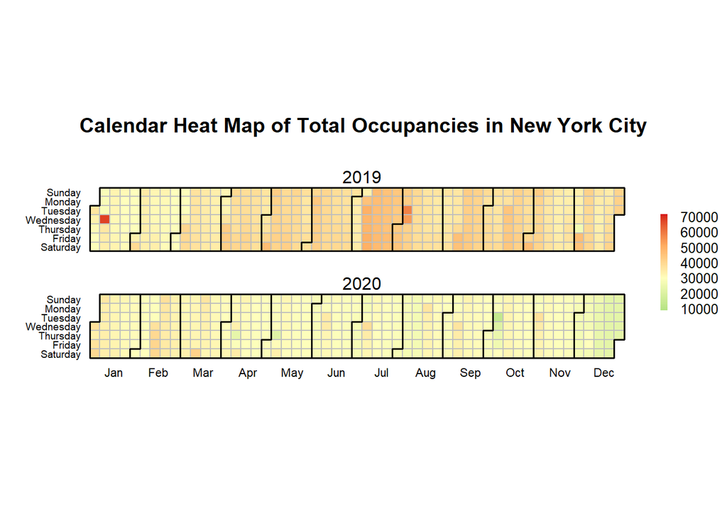

# b. Occupancy Rates in 2019 and 2020

Occupancy rates are severely reduced in 2020.

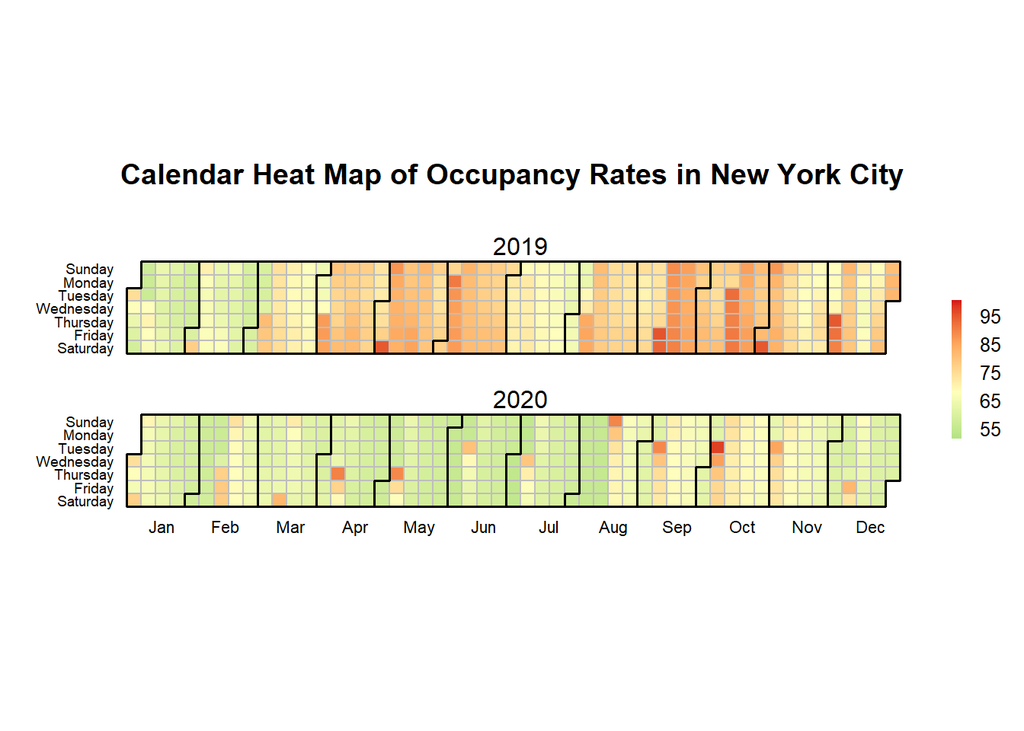

# c. Total Daily Revenue in 2019 and 2020

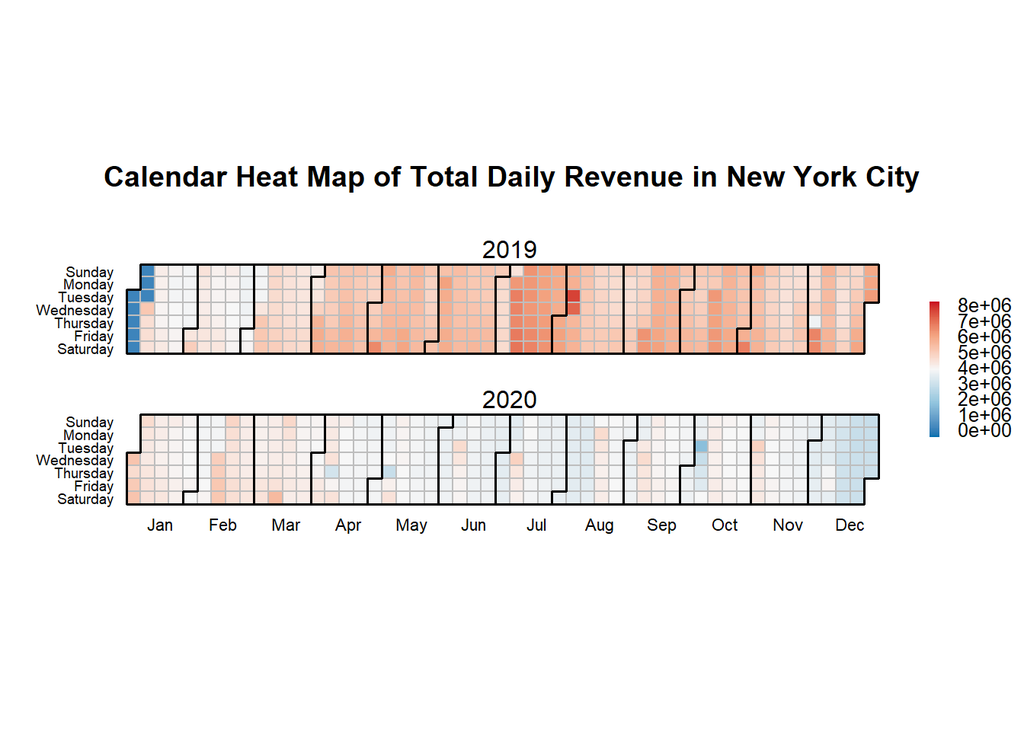

# d. Average Daily Revenue in 2019 and 2020

Average daily revenues are also lower in 2020.

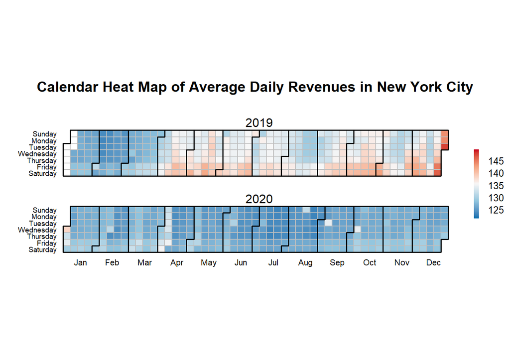

# 2. Seasonal Changes in AirBnB Occupancy and Revenue Generated

We can view the same patterns using line graphs instead.

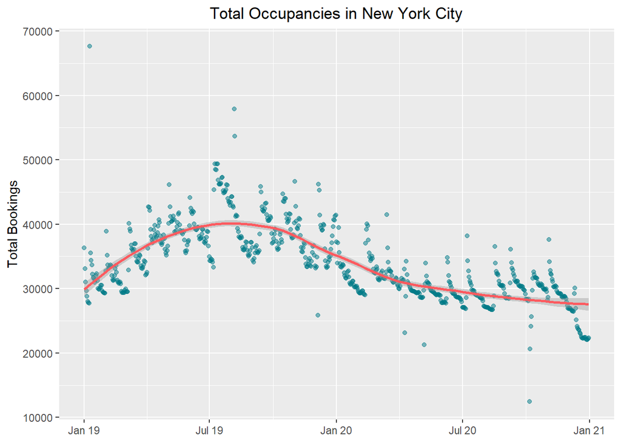

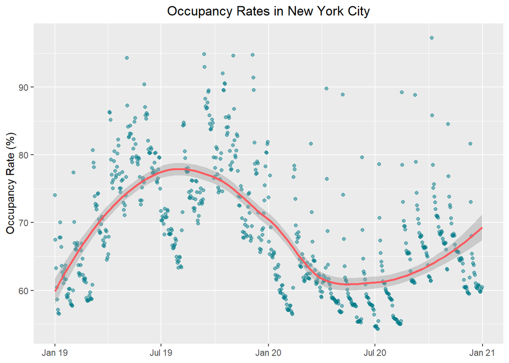

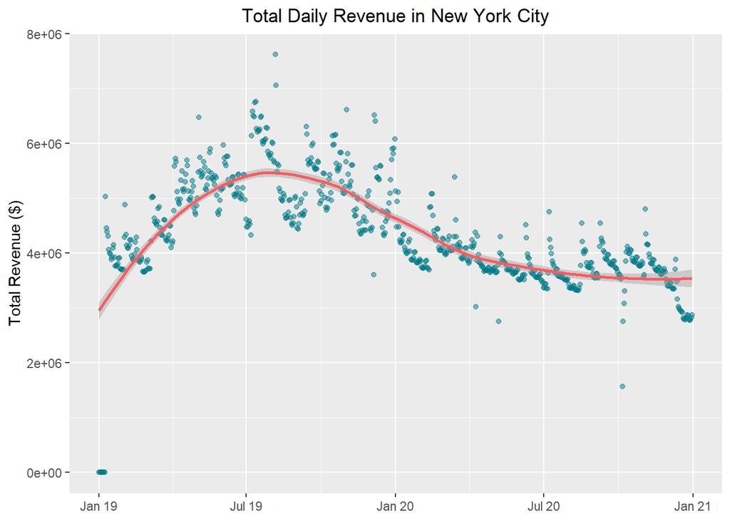

[figure not shown]

# 3. Data Tables on Occupancy and Revenue of AirBnBs in New York City

The data tables allow users to see the number of bookings, listings, percentage of listings booked, total revenue, and average revenue for any day that they select.

|  | date | totalBooked | totalListings | percent_booked |
| --- | --- | --- | --- | --- |
| 1 | 2019-01-01 | 36335 | 49056 | 74.0684116112198 |
| 2 | 2019-01-02 | 33080 | 49056 | 67.4331376386171 |
| 3 | 2019-01-03 | 31030 | 49056 | 63.2542400521853 |
| 4 | 2019-01-04 | 29648 | 49056 | 60.4370515329419 |
| 5 | 2019-01-05 | 28775 | 49056 | 58.6574527071102 |
| 6 | 2019-01-06 | 28029 | 49056 | 57.1367416829746 |
| 7 | 2019-01-07 | 27783 | 49056 | 56.6352739726027 |
| 8 | 2019-01-08 | 27727 | 49056 | 56.5211187214612 |
| 9 | 2019-01-09 | 67618 | 99773 | 67.7718420815251 |
| 10 | 2019-01-10 | 35507 | 50717 | 70.0100557998304 |

[output cut: 721 more lines]

|  | date | totalRevenue | avgRevenue |
| --- | --- | --- | --- |
| 1 | 2019-01-01 | 0 |  |
| 2 | 2019-01-02 | 0 |  |
| 3 | 2019-01-03 | 0 |  |
| 4 | 2019-01-04 | 0 |  |
| 5 | 2019-01-05 | 0 |  |
| 6 | 2019-01-06 | 0 |  |
| 7 | 2019-01-07 | 0 |  |
| 8 | 2019-01-08 | 0 |  |
| 9 | 2019-01-09 | 5027183 | 126.279402160261 |
| 10 | 2019-01-10 | 4459060 | 126.06542082497 |

[output cut: 721 more lines]

# 4. Understanding Trends in AirBnB Reviews

The patterns in the reviews are similar to those in the occupancy and revenue trends.

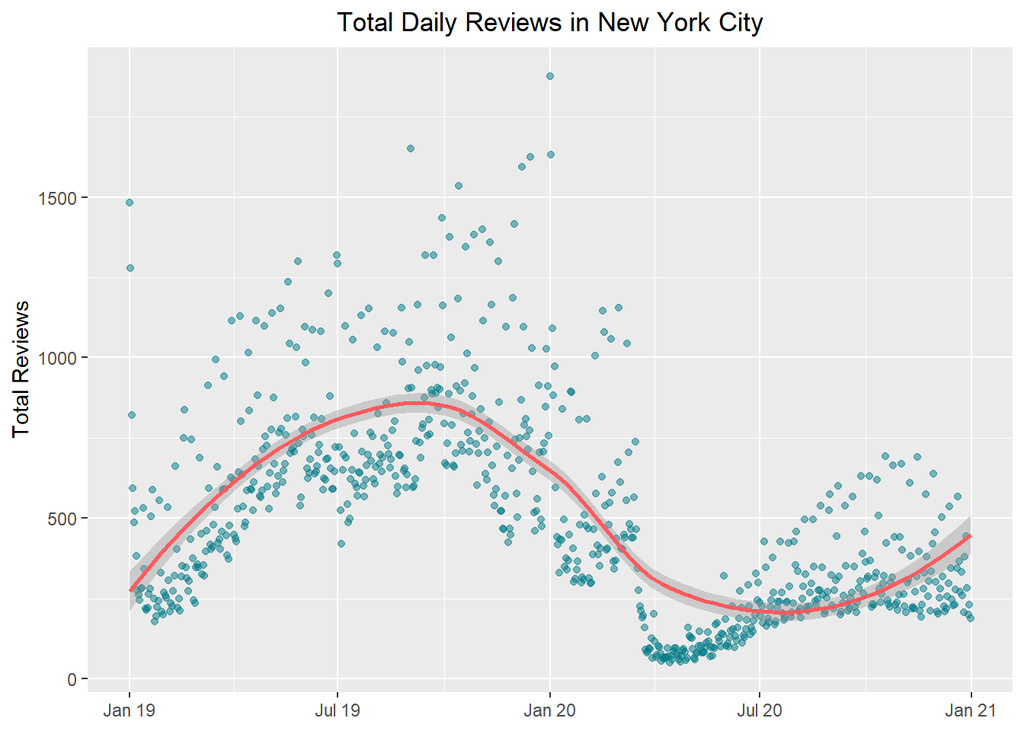

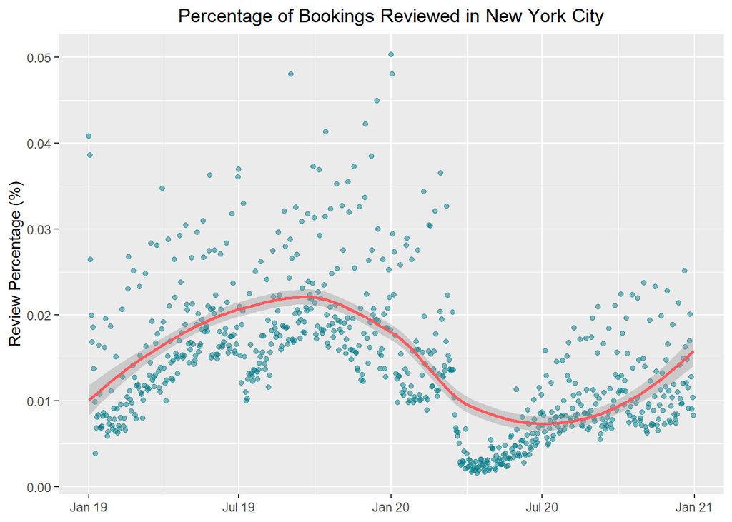

# 5. What Makes a Host a Superhost?

We were interested to know what makes a host a superhost. We believe that response and acceptance rates could be linked closely to it.

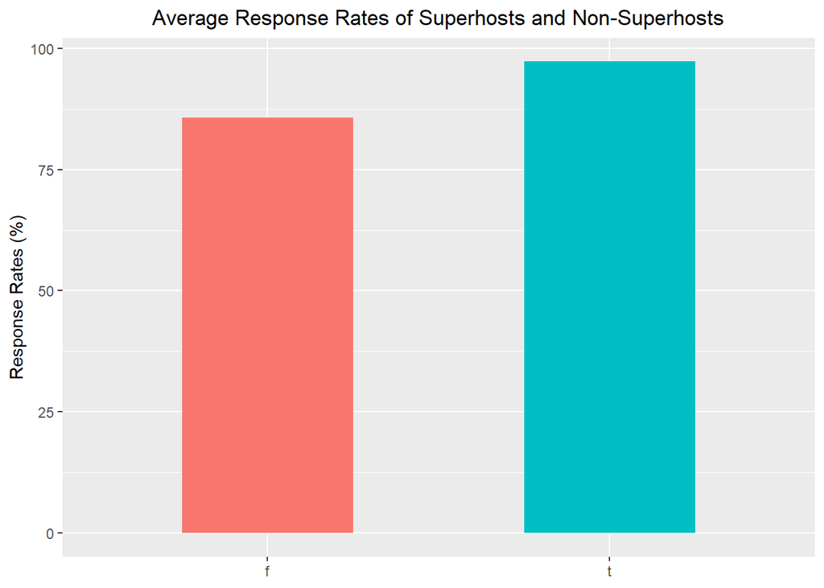

[figure not shown]

```r
ggplot(data = superhost_summary, aes(x = host_is_superhost, y = avgResponse, fill = host_is_superhost)) +
  geom_col(width = 0.5) +
  labs(title = 'Average Response Rates of Superhosts and Non-Superhosts') +
  ylab('Response Rates (%)') +
  theme(plot.title = element_text(hjust = 0.5),
        legend.position = 'none',
        axis.title.x = element_blank())
```